# OLIST RECOMMMEND SYSTEM

Danh sách thành viên nhóm 5:

| STT | MSSV | Họ và Tên |
| --- | --- | --- |
| 28 | 20133082 | Huỳnh Minh Phước |
| 25 | 20133076 | Văn Mai Thanh Nhật |
| 3 | 20133035 | Trần Đông |
| 1 | 20133027 | Nguyễn Hiếu Gia Cường |

## Phần 1 - Tóm tắt

Dự án "Olist Recommend System" tập trung vào việc tối ưu hóa trải nghiệm mua sắm trên nền tảng thương mại điện tử Olist Store. Động lực chính của dự án là nâng cao tỷ lệ khách hàng quay trở lại và mua sắm lần thứ hai trên trang web.

Mặc dù có nhiều loại hình recommend system được đề xuất và sử dụng rộng rãi trong ngành thương mại điện tử, như content-based, knowledge-based, hay collaborative filtering, nhóm nghiên cứu đã chọn đặt trọng điểm vào collaborative filtering. Vì Collaborative filtering dựa trên nguyên lý rằng những người dùng có sở thích tương tự (ví dụ: mua các sản phẩm giống nhau) trong quá khứ sẽ có xu hướng có sở thích tương tự ở tương lai. Nguyên lý này lại khá phù hợp với tập dữ liệu, khi số lần mua hàng của khách hàng tại olist store không cao, đặt biệt chỉ có 4% khách hàng quay lại mua lần thứ hai.

Kết quả của dự án là việc xây dựng một mô hình gợi ý hiệu quả, cho phép cá nhân hóa gợi ý sản phẩm dựa trên hành vi mua hàng cá nhân của từng khách hàng. Mô hình này đã giúp cải thiện trải nghiệm mua sắm của người dùng, tăng cường sự hài lòng và khuyến khích khách hàng quay lại Olist Store để thực hiện các giao dịch tiếp theo.

## Phần 2 - Giới thiệu

Hệ thống gợi ý cho Olist Store là một nỗ lực quan trọng để cải thiện trải nghiệm mua sắm của khách hàng thông qua việc đề xuất sản phẩm phù hợp. Điều này đồng thời giúp tăng cường lượng người dùng trung thành và tăng doanh số bán hàng. Với mục tiêu này, nhóm tập trung vào xây dựng một hệ thống có khả năng cá nhân hóa gợi ý sản phẩm, mục đích chính là tăng cường tương tác và sự hài lòng của khách hàng trên Olist Store.

Bối cảnh của bài toán được xây dựng dựa trên tập dữ liệu thu thập từ năm 2016 đến 2018. Dữ liệu này bao gồm hơn 100,000 đơn hàng từ 96,000 khách hàng khác nhau, nhưng ghi nhận tỷ lệ quay trở lại mua sắm chỉ đạt dưới 5%. Số liệu này cho thấy cần phải có những cải thiện đáng kể để khuyến khích người dùng quay lại mua sắm thường xuyên hơn.

Input của bài toán bao gồm thông tin về khách hàng, người bán, đơn hàng, sản phẩm và đánh giá. Điều này cung cấp một cái nhìn toàn diện về hành vi mua sắm và tương tác giữa các thành phần trong hệ thống.

Để giải quyết bài toán này, nhóm sử dụng thuật toán ALS (Alternating Least Squares) - một phương pháp được chứng minh là hiệu quả trong việc xây dựng các hệ thống gợi ý sản phẩm. Thuật toán này sẽ được áp dụng để đề xuất sản phẩm cho từng khách hàng cũng như gợi ý khách hàng phù hợp cho từng sản phẩm, tạo ra một môi trường mua sắm cá nhân hóa và hấp dẫn trên Olist Store.

## Phần 3 - Dữ liệu

Trong đề tài này, nhóm xin dùng bộ dữ liệu về *Brazilian E-Commerce Public Dataset by Olist* nhằm mục đích xây dựng một hệ thống gợi ý để hỗ trợ cho doanh nghiệp.

Tập dữ liệu này được cung cấp bởi [Olist](https://www.olist.com/), sàn thương mại điện tử lớn nhất tại Brazil. Olist kết nối các cửa hàng, doanh nghiệp nhỏ từ khắp Brazil mà không phải rườm rà, khó khăn về mặt pháp lý. Những người bán hàng này có thể bán các sản phẩm của họ thông qua Olist Store và gửi hàng trực tiếp đến khách hàng bằng cách sử dụng các đối tác vận chuyển của Olist.

Sau khi khách hàng mua sản phẩm từ Olist Store, người bán hàng sẽ nhận được thông báo để thực hiện đơn hàng đó. Khi khách hàng nhận được sản phẩm hoặc đến ngày dự kiến giao hàng, khách hàng sẽ nhận được một bảng khảo sát sự hài lòng qua email, để họ có thể đánh giá trải nghiệm mua hàng và viết nhận xét của mình.

Về nội dung, Tập dữ liệu này chứa thông tin của hơn 100.000 đơn hàng từ năm 2016 đến 2018. Các đặc điểm của nó cho phép xem xét một đơn hàng từ nhiều khía cạnh khác nhau: từ trạng thái đơn hàng, giá cả, thanh toán và hiệu suất vận chuyển đến vị trí của khách hàng, các đặc tính của sản phẩm và cuối cùng là các đánh giá được viết bởi khách hàng.

Tập dữ liệu sau khi được tải về và giải nén và đặt trong thư mục olist_data

### Tiền xử lý dữ liệu

Vì dữ liệu được thu thập từ nhiều bảng được liên kết với nhau bằng khóa ngoại trong cơ sở dữ liệu , đòi hỏi nhóm phải thực hiện các bước tiền xử lý cơ bản trên từng tập dữ liệu. Qua quá trình này, nhóm sẽ chuẩn hóa, làm sạch và điều chỉnh dữ liệu để đảm bảo tính nhất quán. Bao gồm việc xử lý các giá trị bị thiếu, loại bỏ nhiễu, và chuyển đổi dữ liệu sang định dạng thích hợp cho việc phân tích sau này.

Bước tiếp theo là kết hợp chúng lại với nhau thông qua các khóa ngoại vừa đề cập ở trên. Bằng cách này, nhóm có thể tạo ra nhiều tập dữ liệu toàn diện hơn, có khả năng cung cấp cái nhìn toàn diện về quá trình mua bán từ đơn hàng, thông tin sản phẩm đến đánh giá của khách hàng. Quá trình này sẽ giúp nhóm phân tích và rút ra thông tin quan trọng, đồng thời tạo ra các mô hình dự đoán hoặc gợi ý có giá trị từ dữ liệu đã được làm sạch và kết hợp một cách cẩn thận.

Tất cả những việc này được nhóm xử lý trong file **1data_cleaning.ipynb**, cùng với việc sử dụng SPARK để tối ưu hơn trong quá trình xử lý dữ liệu lớn

Việc này sẽ được lần lượt thực hiện theo các bước sau:

#### 1. Xử lý dữ liệu thiếu

Do khối lượng dữ liệu lớn, khoảng 100.000 dòng, nhưng tỷ lệ dữ liệu thiếu khá thấp, dưới 100 dòng, nhóm quyết định lựa chọn xoá các dòng dữ liệu thiếu này. Quyết định này được đưa ra với niềm tin rằng việc loại bỏ những điểm dữ liệu thiếu nhỏ này sẽ không gây ảnh hưởng đáng kể đến tính toàn vẹn và chất lượng tổng thể của tập dữ liệu. Việc này cũng giúp nhóm tập trung vào việc xử lý và phân tích dữ liệu chính xác hơn, đồng thời giảm thiểu rủi ro phát sinh từ việc sử dụng dữ liệu không đầy đủ hoặc không chính xác.

#### 2. Chuẩn hoá dạng dữ liệu của từng thuộc tính

Khi làm việc với Spark DataFrame, có thể xảy ra trường hợp không xác định được loại dữ liệu chính xác của từng cột. Điều này đặt ra yêu cầu cho nhóm phải tiến hành kiểm tra và xác định lại thuộc tính cho từng tập dữ liệu. Sau khi xác định những cột sai sót, nhóm tiếp tục thực hiện chuẩn hóa dữ liệu, có thể chuyển đổi từ dạng chuỗi (string) sang các định dạng khác như timestamp hoặc số nguyên (int), tùy thuộc vào nội dung và mục đích của từng cột.

Bước chuẩn hoá này giúp nhóm tối ưu hóa hiệu suất phân tích và sử dụng dữ liệu trong quá trình thực hiện các phân tích và mô hình hóa sau này.

#### 3. Lọc những thông tin cần thiết

Trong quá trình lọc dữ liệu theo cả chiều ngang và dọc, nhóm đã thực hiện việc loại bỏ những cột không cần thiết. Ví dụ, trong tập dữ liệu về đánh giá (reviews), nhóm đã loại bỏ hai cột "Tiêu đề đánh giá" và "Nội dung đánh giá" được viết bằng tiếng Bồ Đào Nha, vì chúng không được sử dụng trong quá trình phân tíchs.

Tương tự, trong bảng orders, nhóm đã xóa những đơn hàng đã bị huỷ. Vì những đơn hàng này thường sẽ không có review và không đánh giá được mức độ tương quan giữa người mua với sản phẩm. Việc loại bỏ này giúp nhóm tập trung vào các đơn hàng hoàn tất và có tính nhất quán. Điều này cũng đồng nghĩa với việc loại bỏ các yếu tố không cần thiết, giúp tăng độ chính xác và đáng tin cậy của quá trình nghiên cứu và phân tích dữ liệu.

#### 4. Kết hợp tập dữ liệu

Sau khi hoàn thiện các bước trên, các tập dữ liệu đã có vẻ ổn định và sẵn sàng cho các bước sau. Việc tiếp theo là kết hợp các tập dữ liệu riêng lẻ với nhau để tạo ra ba tập dữ liệu chính có chức năng và mục tiêu khác nhau.

Tập dữ liệu "master" được xây dựng với mục đích chính là để sử dụng trong quá trình mô hình hóa. Nó chứa các thông tin được tối ưu hóa để phục vụ cho việc xây dựng và đánh giá mô hình chung. Ta có thể sử dụng tập dữ liệu này cho nhiều mô hình khác nhau.

"Tập dữ liệu khách hàng" (customers) chứa thông tin liên quan đến quá trình mua hàng của khách hàng, bao gồm các thông tin như hành vi mua sắm, lịch sử đặt hàng và các thuộc tính cá nhân của khách hàng. Ở bài báo cáo này, ta sẽ tập trung phân tích ở tập dữ liệu này

"Tập dữ liệu người bán" (sellers) tập trung vào các thông tin liên quan đến quá trình bán hàng của người bán, bao gồm các thông tin về sản phẩm, hiệu suất bán hàng và các thuộc tính của người bán.

Hai tập dữ liệu về khách hàng hay người bán sẽ được dùng để phân tích, đơn cử là EDA sử dụng tập customers, ngoài ra còn có thể phân tích sâu hơn vào 2 tập dữ liệu ấy trong tương lai.

Để đảm bảo sự nhất quán và tương thích giữa hai tập dữ liệu "customers" và "sellers", nhóm đã tiến hành việc lọc dữ liệu bằng cách chỉ giữ lại những đơn hàng xuất hiện trong cả hai tập.

Cuối cùng, 3 tập dữ liệu hoàn chỉnh được lưu lại vào thư mục clean_data

## Phần 4 - Trực quan hóa dữ liệu

### Which product type generated the most profit?

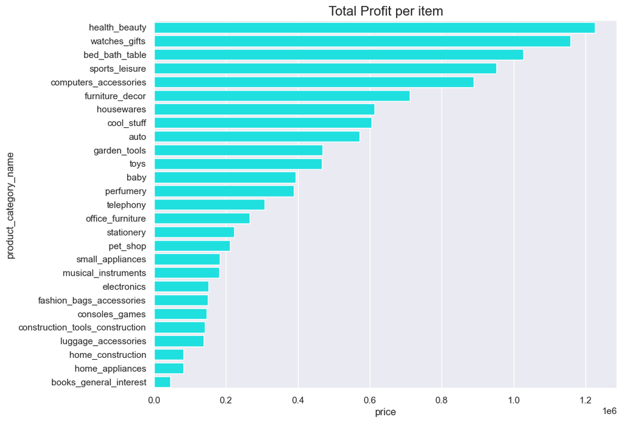

> Theo phân tích trên, top 5 danh mục sản phẩm mang lại lợi nhuận cao nhất cho Olist bao gồm: Sức khỏe và sắc đẹp, đồng hồ, đồ dùng phòng ngủ và phòng tắm, thể thao và giải trí và cuối cùng là phụ kiện máy tính

> Trong khoảng thời gian 2 năm gần đây, có tới 11 mặt hàng đã mang lại doanh thu trên 400 nghìn đồng.

### Which products are purchased most frequently?

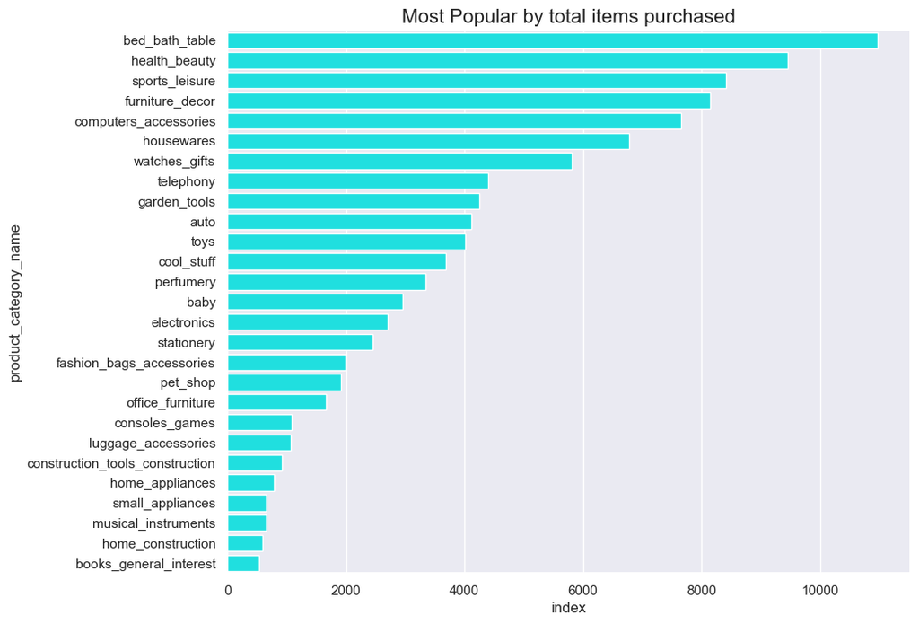

### Which product has the highest average cost for the customer?

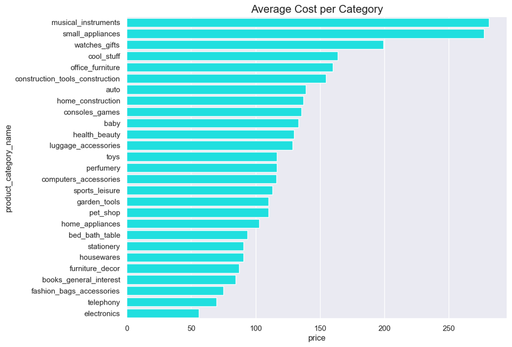

> Không có gì ngạc nhiên khi thấy đồng hồ và các loại quà tặng nằm trong top 5 mặt hàng mang lại giá trị trung bình cao nhất, trong khi đồ thể thao giải trí lại không nằm trong top 15, điều này xác nhận những giả định trước đó. Nhạc cụ, đồ gia dụng nhỏ và đồng hồ, quà tặng là những mặt hàng đắt nhất. Một phát hiện thú vị đó là đồng hồ, quà tặng và các sản phẩm tự động là hai nhóm duy nhất lọt vào top 10 về chi phí trung bình, lợi nhuận và được mua thường xuyên.

### What are the highest rated products?

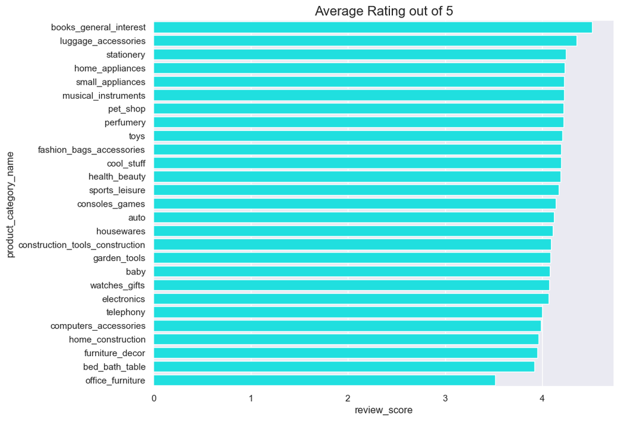

> Có vẻ như nhiều sản phẩm có doanh thu cao thì không có nghĩa rằng nó cũng được đánh giá cao trong bảng điểm đánh giá trung bình, ngoại trừ sức khỏe, sắc đẹp và thể thao giải trí. Đồ gia dụng nhỏ được đánh giá cao và có giá trung bình cao, nhưng đây là một danh mục nằm ở mức thấp về lợi nhuận và số lần mua.

### Exploring Seasonal Trends

Để thực hiện phân tích này, chúng ta sẽ chuyển sang chế độ xem theo năm bắt đầu từ tháng 7 năm 2017 đến tháng 7 năm 2018. Olist trong năm 2017 vẫn đang phát triển, tự quảng bá rộng rãi hơn vào ngày black friday năm 2017. Việc tăng trưởng doanh số trong khoảng thời gian được ghi nhận sẽ cung cấp 1 tương lai về xu hướng tăng trưởng hàng năm của họ sau thời điểm này. Đối với mỗi biểu đồ bên dưới, việc tổng hợp được thực hiện bằng cách sử dụng ngày và giờ mua hàng, trái ngược với thời gian giao hàng hoặc ghi nhận trong hệ thống. Điều này sẽ cho mang lại một góc nhìn tốt hơn về khách hàng và thuận tiện cho chúng ta ghi nhận bất kỳ xu hướng mua hàng theo mùa nào.

### When is Olist receiving the most profit?

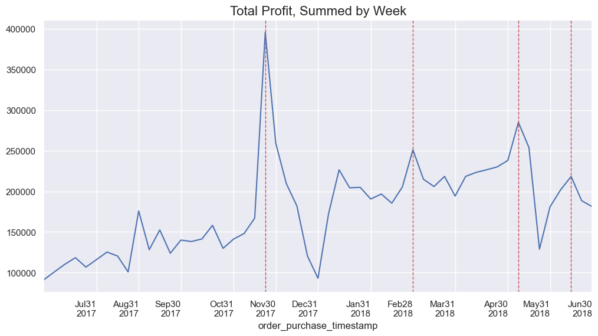

### How many products were they selling per week over the same period?

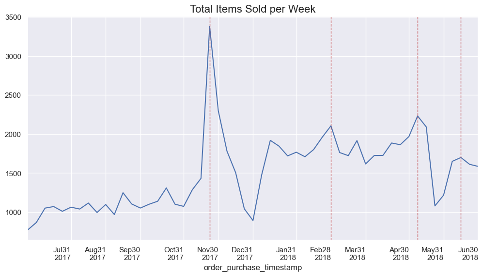

### How do review scores change over time? Are there any seasonal trends?

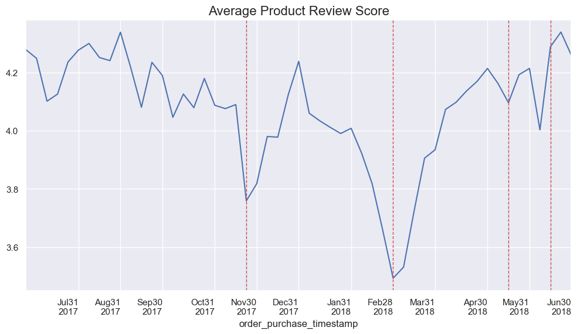

> Điểm đánh giá trung bình giảm trong các giai đoạn mua hàng với số lượng lớn. Các đường thẳng đứng được ghi chú ở trên tương ứng với giai đoạn có số lượng lớn được ghi chú trong biểu đồ trước đó. Tuy nhiên, có hai điểm khác biệt, vào ngày 28 tháng 2 có một sự gia tăng nhỏ về doanh số tuy nhiên kèm theo đó là một sự sụt giảm lớn về điểm đánh giá. Ngoài ra, có thể thấy trong biểu đồ trên, sự gia tăng doanh số vào giữa tháng 6 không tương quan với sự sụt giảm trước đó trong tháng. Có thể có một số nguyên nhân gây nhiễu ở đây, hoặc một thách thức theo mùa với thời gian giao hàng ảnh hưởng đến đánh giá cần được điều tra thêm.

### During what seasons are late delivery times the most significant? How does this affect customer satisfaction?

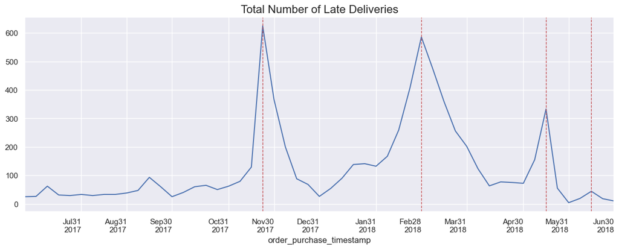

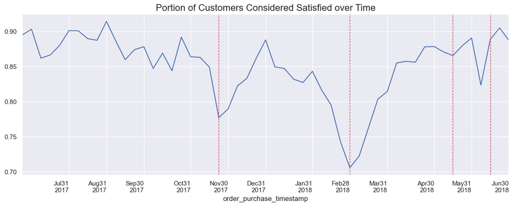

> Phân tích trên chỉ ra rằng tồn tại mối quan hệ rõ ràng giữa mức độ hài lòng của khách hàng và thời gian giao hàng đúng hạn. Số lượng khách hàng hài lòng suy giảm đáng kể trong ba giai đoạn cao điểm về số lượng đơn hàng. Tuy nhiên, có một điểm giảm vào ngày 6 tháng 6 không được giải thích. Đây có thể là một ngày cần phải điều tra để xem xét những loại sản phẩm nào đã được mua và tại sao khách hàng lại không hài lòng.

> Giờ chúng ta cũng xác định được nguyên nhân gây ra sự sụt giảm đến điểm đánh giá sản phẩm trung bình được xác định trước đó vào ngày 28 tháng 2. Mặc dù ngày này không có số lượng đơn hàng được đặt mua như black friday, nhưng nó lại có số lượng giao hàng muộn gần như nhau.

### Investigating June 6th drop in customer satisfaction

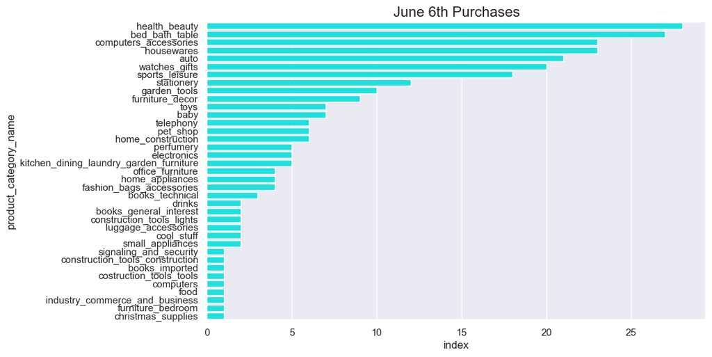

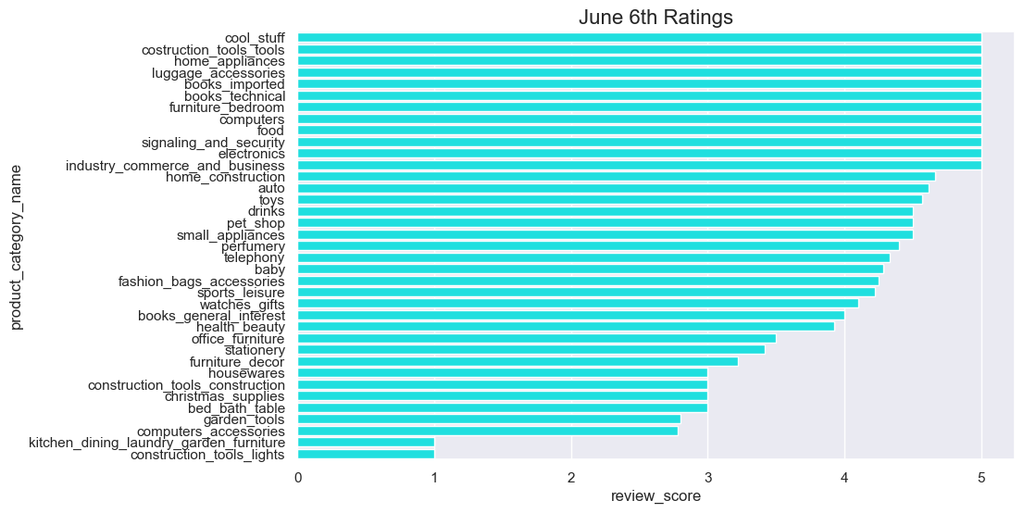

> Thật đáng ngạc nhiên, chỉ có 3 đơn hàng bị giao chậm vào ngày 6 tháng 6, hai trong số đó được đánh giá là không đạt yêu cầu.

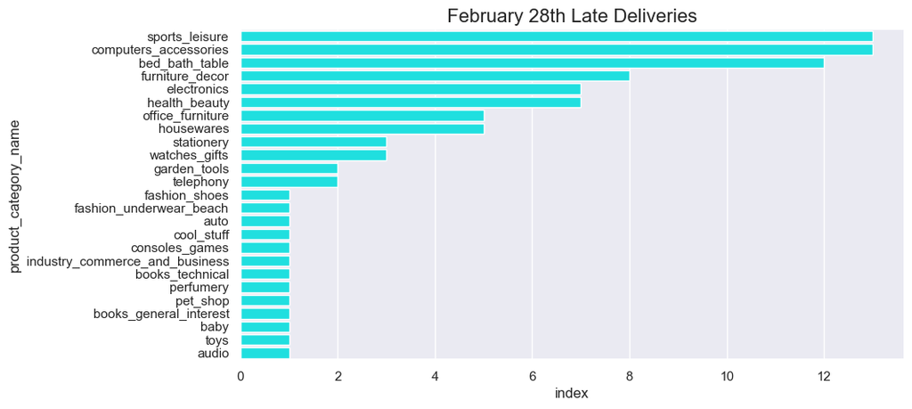

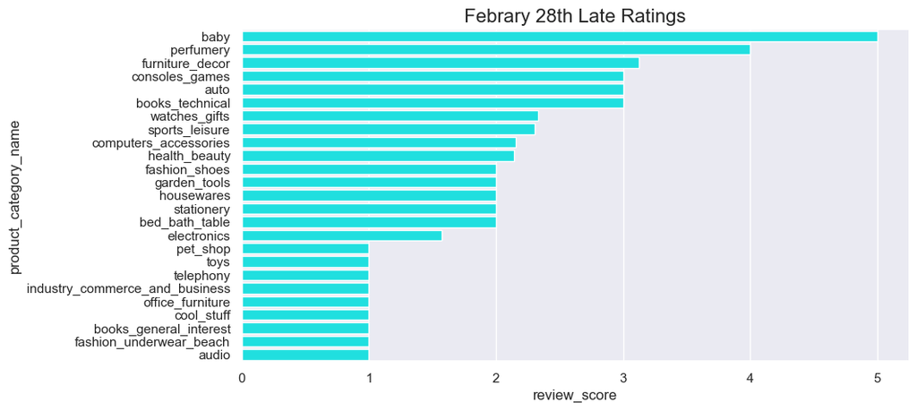

> Nhiều mặt hàng khác được giao trễ vào ngày 28 tháng 2, trong số đó nhiều đơn hàng chỉ được đánh giá ở mức 3 trở xuống. Đáng chú ý, đồ thể thao giải trí và phụ kiện máy tính chiếm phần lớn các mặt hàng giao trễ và có điểm đánh giá trung bình dưới 3.

### Summary from Exploratory Phase

> Giai đoạn phân tích đã tiết lộ một số yếu tố thú vị ảnh hưởng đến mức độ hài lòng của khách hàng, trong đó yếu tố có tầm ảnh hưởng mạnh nhất là thời gian giao hàng. nhóm cũng nhận thấy rằng nhiều danh mục phổ biến nhất cũng là những danh mục được đánh giá thấp nhất. Điều này có thể đơn giản là do thực tế các mặt hàng được mua nhiều hơn, dẫn đến việc tỷ lệ người dùng đánh giá thấp cũng nhiều hơn, cũng có thể có nhiều yếu tố khác góp phần vào xếp hạng thấp hơn.

> Sau khi điều tra trường hợp nghiên cứu vào ngày 6 tháng 6, ta vẫn thấy rằng có trường hợp các danh mục với xếp mức xếp hạng thấp vẫn nhận được điểm thấp mặc dù các mặt hàng được giao đúng hạn.

> Những thách thức mà nhóm phải đối mặt trong việc tạo ra hệ thống đề xuất của mình sẽ là việc đề xuất những mặt hàng có thể phù hợp với thói quen mua sắm của khách hàng nhưng không được mua nhiều bởi người khác. Để giải quyết vấn đề này, cách tiếp cận của nhóm sẽ dựa vào một phương pháp kết hợp, không chỉ xem xét những gì khách hàng khác đã mua mà còn cả thông tin về người dùng và sản phẩm họ đã mua. Điều này sẽ giúp giải quyết một vấn đề phổ biến đối với các hệ thống đề xuất, đó là vấn đề “bắt đầu lạnh” phát sinh với khách hàng mới (chưa mua gì nên không có dữ liệu để đề xuất). Đối với mục đích xây dựng hệ thống của nhóm, nó cũng sẽ giúp ích cho những khách hàng chỉ mua hàng từ Olist một lần.

## Phần 5 - Mô hình hóa dữ liệu

Trong phần này, chúng ta sẽ chi tiết hơn về các thuật toán và mô hình mà nhóm đã chọn sử dụng. Đầu tiên, chúng ta sẽ tìm hiểu về thuật toán phân rã ma trận (Matrix Factorization), một phương pháp mạnh mẽ cho việc xử lý dữ liệu lớn và lọc cộng tác. Tiếp theo, chúng ta sẽ đi sâu vào Mô hình lọc cộng tác Alternating Least Squares (ALS), một công cụ quan trọng trong việc dự đoán và gợi ý dựa trên hành vi người dùng. Cuối cùng, ta sẽ tập trung vào quá trình Tinh chỉnh siêu tham số thông qua Cross Validation, một phương pháp quan trọng giúp tìm ra cấu hình tối ưu nhất cho mô hình của chúng ta.

### 5.1 Phân rã ma trận

Trong lọc cộng tác, phân rã ma trận là giải pháp tiên tiến cho vấn đề dữ liệu thưa thớt, từ khi nó trở nên phổ biến kể từ cuộc thi Netflix Prize.

Phân rã ma trận là một phép toán ma trận trong đại số tuyến tính. Cụ thể, phân rã ma trận là việc phân rã một ma trận thành tích của các ma trận. Trong trường hợp lọc cộng tác, các thuật toán phân rã ma trận hoạt động bằng cách phân rã ma trận tương tác người dùng-sản phẩm thành tích của hai ma trận hình chữ nhật có số chiều nhỏ hơn. Một ma trận có thể được xem như ma trận người dùng với hàng biểu diễn người dùng và cột là yếu tố ẩn. Ma trận còn lại là ma trận sản phẩm với hàng là yếu tố ẩn và cột biểu diễn sản phẩm.

[figure not shown]

Trong ma trận tương tác người dùng-sản phẩm thưa thớt, điểm đánh giá dự đoán mà người dùng u sẽ đánh cho sản phẩm i được tính như sau:

[figure not shown]

Điểm đánh giá của sản phẩm i dành cho người dùng u có thể được biểu diễn như một tích vô hướng của vector ẩn người dùng và vector ẩn của sản phẩm.

Lưu ý trong công thức trên, số lượng yếu tố ẩn (latent factor) có thể được điều chỉnh thông qua cross validation. Yếu tố ẩn là các đặc trưng trong không gian ẩn ít chiều được chiếu từ ma trận tương tác người dùng-sản phẩm.

Ở đây, số lượng latent factor xác định số lượng thông tin trừu tượng mà chúng ta muốn lưu trữ trong không gian ít chiều. Một ma trận phân rã với một latent factor thì sẽ tương đương với hệ thống gợi ý phổ biến nhất (ví dụ:hệ thống sẽ gợi ý các sản phẩm có tương tác nhiều nhất mà không có tính cá nhân hóa nào). Khi tăng số lượng latent factor sẽ cải thiện tính cá nhân hóa trong việc gợi ý, nhưng cho đến khi số lượng này nên quá nhiều, khi đó mô hình bắt đầu overfitting. Chiến lược phổ biến để tránh việc này là thêm các regularization terms vào hàm mục tiêu.

Mục tiêu của phân rã ma trận là tối thiểu hóa sai số giữa điểm đánh giá thực và điểm đánh giá dự đoán:

[figure not shown]

Khi đã có hàm hàm mục tiêu, chúng ta chỉ cần một quy trình huấn luyện (ví dụ: gradient descent) để hoàn tất việc triển khai của một thuật toán phân rã ma trận. Triển khai này thực tế được gọi là Funk SVD. Nó được đặt theo tên Simon Funk, người đã chia sẻ các kết quả của mình với cộng đồng nghiên cứu trong cuộc thi Netflix prize vào năm 2006.

### 5.2 Mô hình lọc cộng tác Alternating Least Square (ALS)

Alternating Least Square (ALS) là một thuật toán phân rã ma trận và nó hoạt động theo cách song song. ALS được triển khai trong Apache Spark ML và được xây dựng cho các vấn đề lọc cộng tác quy mô lớn. ALS đã làm rất tốt trong việc giải quyết vấn đề về quy mô và tính thưa thớt của dữ liệu Đánh giá, nó đơn giản và có khả năng mở rộng tốt với các tập dữ liệu rất lớn.

Một số ưu điểm của ALS:

- Hàm mục tiêu của nó hơi khác so với Funk SVD: ALS sử dụng điều chuẩn L2 trong khi Funk sử dụng điều chuẩn L1.
- Quy trình huấn luyện của nó khác nhau: ALS tối thiểu hóa hai hàm mất mát xen kẽ; trước tiên nó giữ ma trận người dùng cố định và chạy gradient descent với ma trận sản phẩm; sau đó giữ ma trận sản phẩm cố định và chạy gradient descent với ma trận người dùng.
- Tính khả thi: ALS chạy gradient descent song song trên nhiều phân vùng của dữ liệu huấn luyện cơ bản từ một cụm máy.

Tương tự như các thuật toán học máy khác, ALS có bộ siêu tham số riêng của nó. Chúng ta có thể điều chỉnh siêu tham số của nó thông qua hold-out validation hoặc cross-validation.

Các siêu tham số quan trọng trong ALS bao gồm:

- maxIter: số lần lặp tối đa để chạy (mặc định là 10)
- rank: số lượng yếu tố ẩn trong mô hình (mặc định là 10)
- regParam: tham số điều chuẩn trong ALS (mặc định là 1.0)

### 5.3 Tinh chỉnh siêu tham số với CrossValidator

Một trong những nhiệm vụ quan trọng trong Machine Learning là lựa chọn mô hình, hoặc sử dụng dữ liệu để tìm ra mô hình hoặc tham số tốt nhất cho một nhiệm vụ cụ thể.

Việc điều chỉnh có thể được thực hiện cho từng Estimator riêng như LogisticRegression, hoặc cho toàn bộ Pipeline bao gồm nhiều thuật toán, biến đổi đặc trưng và các bước khác. Người dùng có thể điều chỉnh toàn bộ Pipeline cùng một lúc, thay vì điều chỉnh từng phần tử trong Pipeline một cách riêng lẻ.

Cross Validation là một trong những mô hình tinh chỉnh tham số, nó bắt đầu bằng cách chia tập dữ liệu thành một tập các fold được sử dụng như các tập train và test riêng biệt. Ở đây, pyspark có hỗ trợ mô hình đó với tên hàm là CrossValidator

[figure not shown]

Trong ví dụ này, chúng ta sử dụng k=5 folds (ở đây k là số lần chia tập dữ liệu thành các mẫu train và test), Cross validator sẽ tạo ra 5 cặp tập dữ liệu (train, test), mỗi cặp sử dụng 4/5 dữ liệu để train và 1/5 dữ liệu để test cho mỗi vòng lặp.

Để đánh giá một siêu tham số cụ thể, CrossValidator tính toán chỉ số đánh giá trung bình cho 5 Mô hình được tạo ra bằng cách fitting Estimator trên 5 cặp tập dữ liệu (train, test) khác nhau.

Sau khi xác định được siêu tham số tốt nhất, CrossValidator fit lại Estimator bằng siêu tham số tốt nhất đó trên toàn bộ tập dữ liệu.

Cách thức hoạt động của Cross Validator như sau:

- Chia dữ liệu đầu vào thành các tập dữ liệu train và test riêng biệt.
- Đối với mỗi cặp (train, test), lặp qua tập ParamMap với từng cặp
- Đối với mỗi ParamMap, fit Estimator bằng các tham số đó, lấy mô hình đã fit và đánh giá hiệu suất của mô hình bằng Evaluator.
- Cuối cùng, chọn mô hình được tạo ra từ bộ tham số hoạt động tốt nhất.

## Phần 6 - Thực nghiệm, kết quả, và thảo luận

Từ tập dữ liệu master, nhóm tiến hành bước đầu của mô hình hoá bằng cách lọc các thông tin quan trọng như customer_unique_id, product_id và review_score để tạo ra tập user_features phục vụ cho mô hình ALS. Đồng thời, nhóm cũng lọc các cột product_id và product_category_name cho tập item_ features để sử dụng cho hàm recommended trên mô hình đã được huấn luyện.

Nhóm tiếp tục áp dụng kỹ thuật StringIndex cho 2 cột customer_unique_id và product_id từ tập user_features.Kỹ thuật StringIndexer là một tính năng quan trọng trong PySpark giúp chuyển đổi các cột chuỗi phân loại trong DataFrame thành chỉ số. Việc chuyển đổi này là cần thiết vì hầu hết các thuật toán học máy không thể làm việc trực tiếp với dữ liệu chuỗi.

Sau đó, nhóm huấn luyện một mô hình với các tham số cơ bản mà không sử dụng cross-validation, phân chia dữ liệu thành tập train 80% và tập test 20% với các tham số cơ bản .Kết quả kiểm tra trên tập test cho thấy mô hình đạt được chỉ số RMSE từ 0,7 đến 0,8, cùng các chỉ số khác khá ổn, cho thấy mức độ hiệu quả của mô hình không quá tệ.

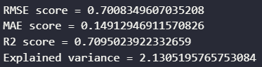

Vì những độ đánh giá không gây khó khăn gì, nhóm tiến hành sử dụng cross-validation để lựa chọn bộ tham số tốt nhất cho mô hình. Với số folds được nhóm chọn là 5 để tối ưu thời gian huấn luyện, nhóm thử nghiệm với bộ tham số als.rank = [10, 50, 100, 150] và als.regParam = [.01, .05, .1, .15]. Quá trình này tạo ra tổng cộng 80 mô hình để so sánh và lựa chọn ra mô hình tối ưu nhất. Một lần nữa xem qua độ đánh giá cho mô hình tốt nhất đã được chọn.

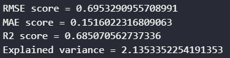

Cuối cùng, nhóm thực hiện huấn luyện lại mô hình với bộ tham số tốt nhất trên toàn bộ tập dữ liệu, từ đó tạo ra mô hình cuối cùng cho việc dự đoán và đề xuất sản phẩm.

Cùng lướt qua một số gợi ý cho vài khách hàng bất kì dưới đây:

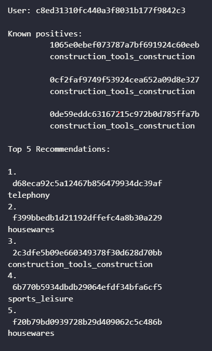

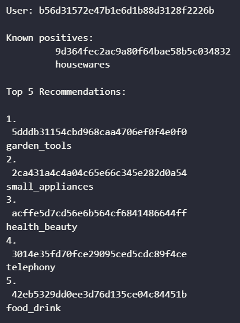

[figure not shown]

## Phần 7 - Kết luận

Để xây dựng một hệ thống gợi ý, đòi hỏi sự kết hợp linh hoạt của nhiều phương pháp và công cụ khác nhau. Chặng đường bắt đầu từ việc xử lý dữ liệu để làm sạch và chuẩn bị, đến việc phân tích khám phá sâu hơn (EDA), hiểu rõ hơn về những đặc điểm ẩn sau dữ liệu. Cuối cùng là quá trình xây dựng mô hình và điều chỉnh các tham số, một công việc mất thời gian và tập trung. Qua quá trình này, nhóm đã có cơ hội tìm hiểu và triển khai các thuật toán học máy trên dữ liệu lớn và phức tạp.

Khi mô hình cuối cùng đã hình thành, nhóm hy vọng rằng nó sẽ không chỉ giúp tăng doanh số cho doanh nghiệp mà còn thúc đẩy sự trung thành và tái mua hàng của người dùng. Việc gợi ý sản phẩm một cách chính xác hơn không chỉ tạo ra một trải nghiệm mua sắm tốt hơn mà còn có thể đáp ứng nhu cầu và sở thích cá nhân của từng khách hàng.

Tuy nhiên, vì thời gian hạn chế đã khiến nhóm không thể khám phá hết tiềm năng của tập dữ liệu. Cũng như chưa thể áp dụng những mô hình gợi ý phức tạp và cá nhân hóa hơn để tối ưu hóa hơn nữa trải nghiệm của từng người dùng.

Cuối cùng, nhóm xin cảm ơn thầy đã cho nhóm cơ hội thực hiện đề tài này. Nhóm hy vọng rằng đề tài của nhóm sẽ có tác động nhỏ trong việc cải thiện chất lượng dịch vụ của nhiều doanh nghiệp, cũng như mở ra các hướng nghiên cứu mới trong tương lai. Một lần nữa, nhóm xin cảm ơn tất cả mọi người đã đọc và quan tâm đến đề tài. Xin cảm ơn!

## Phần 8 - Phụ lục

## Phần 9 - Đóng góp

Bảng phân công nhiệm vụ nhóm 5:

| MSSV | Họ và Tên | Nhiệm vụ | Hoàn thành |
| --- | --- | --- | --- |
| 20133076 | Văn Mai Thanh Nhật | Implement cross-validation | 100% |
| 20133082 | Huỳnh Minh Phước | Implement ALS, recommended function | 100% |
| 20133035 | Trần Đông | Date pre-processing | 100% |
| 20133027 | Nguyễn Hiếu Gia Cường | EDA | 100% |

## Phần 10 - Tham khảo

Olist, Brazilian E-Commerce Public Dataset by Olist, Kaggle, 2021, đường dẫn: https://www.kaggle.com/datasets/olistbr/brazilian-ecommerce

Kevin Liao, Prototyping a Recommender System Step by Step Part 2: Alternating Least Square (ALS) Matrix Factorization in Collaborative Filtering, TowardsDataScience, 2018, đường dẫn: https://towardsdatascience.com/prototyping-a-recommender-system-step-by-step-part-2-alternating-least-square-als-matrix-4a76c58714a1

Srinivas Gaddam, Machine Learning Model Selection and Hyperparameter Tuning using PySpark, Medium, 2020, đường dẫn:https://medium.com/@srinivasugaddam/machine-learning-model-selection-and-hyperparameter-tuning-using-pyspark-80dd8c1bfc56

Matthew Merrill, Analysis of the Olist dataset, Github, 2021, đường dẫn: https://github.com/merrillm1/Olist_Recommender_System/tree/master